# Creating Figures 3, 4 and 5

# Preamble

This is an Electronic Supplement to the manuscript Schwacke et al. 2022. Modeling population effects of the Deepwater Horizon oil spill on a long-lived species. $Conservation~Biology$ 36:e13878 DOI: https://doi.org/10.1111/cobi.13878

The master file containing links to all supplementary files related to this paper is BND_Electronic Supplements master file.

If you make use of any of this material in your work, it would be appreciated if you would contact Tiago Marques to let him know.

# Introduction

```r
#a function required to get some values
source("Functions/reqfuns.R")
```

# Creating figure 3

To update the distributions from Schwacke et al 2017, experts were asked: “Given that the value of $\rho$ will affect the shape of the density dependent response of fecundity in the [BSE and coastal bottlenose dolphin/Gulf of Mexico] population, what do you judge to be the most appropriate value for Rho for this species and population?”

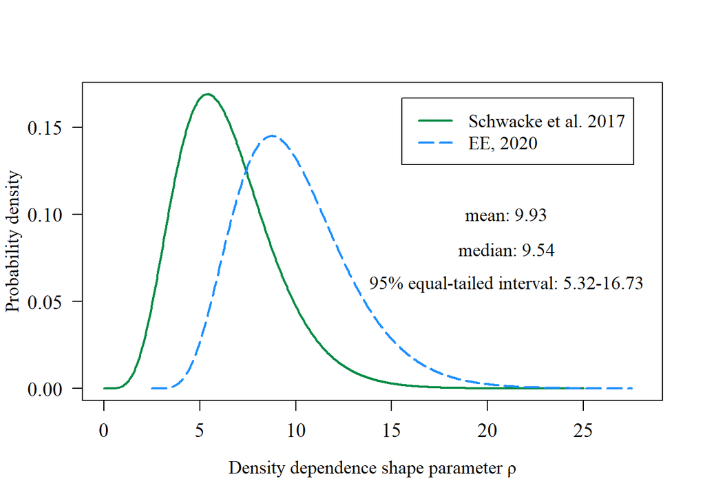

```r
library(latex2exp)  # for tex in plot labels
windowsFonts(A = windowsFont("Times New Roman"))
x <- seq(0.001, 25, length = 1000)
# Our old distribution
old.shape <- 6.4
old.scale <- 1
q <- dgamma(x, shape = old.shape, scale = old.scale)
# q3 <- dgamma(x, shape = 5.53, scale = 1/0.745) This is
# the one we chose, represented in red q2 <- dgamma(x,
# shape = shape, scale = scale)
plot(x, q, type = "l", col = "springgreen4", lwd = 2, xlim = c(0,
    28), xlab = expression(paste("Density dependence shape parameter ",
    rho)), ylab = "Probability density", las = 1, family = "A",
    cex.axis = 1.2, cex.main = 1.5, cex.lab = 1.1)
# lines(x + lower, q2, type = 'l', col = 'red') lines(x,
# q3, type = 'l', col = 'blue', lty = 2)

SpInfo <- getSpData("Ttru")
q3 <- with(SpInfo, dgamma(x, shape = rhoshape, scale = rhoscale))
lines(x + SpInfo$rhoshift, q3, type = "l", lwd = 2, lty = 5,
    col = "dodgerblue")

# q4 <- dgamma(x, shape = 5.02, rate = 0.652) lines(x + 3,
# q4, type = 'l', lwd=3, lty=5, col = 'dodgerblue')
op <- par(family = "A")

legend("topright", legend = c("Schwacke et al. 2017", "EE, 2020"),
    col = c("springgreen4", "dodgerblue"), lty = c(1, 5), lwd = 2,
    cex = 1.1, inset = 0.05)

par(op)


rhos <- with(SpInfo, (rhoshift + rgamma(1000000, shape = rhoshape,
    scale = rhoscale)))
text(21, 0.1, labels = paste("mean:", round(mean(rhos), 2)),
    family = "A", cex = 1.1)
text(21, 0.08, labels = paste("median:", round(median(rhos),
    2)), family = "A", cex = 1.1)
text(21, 0.06, labels = paste0("95% equal-tailed interval: ",
    round(quantile(rhos, p = 0.025), 2), "-", round(quantile(rhos,
        p = 0.975), 2)), family = "A", cex = 1.1)
```

The bottlenose dolphin fecundity as a function of population size based on the above distributions for $\rho$ are represented below as the fecundity rate as a function of population size:

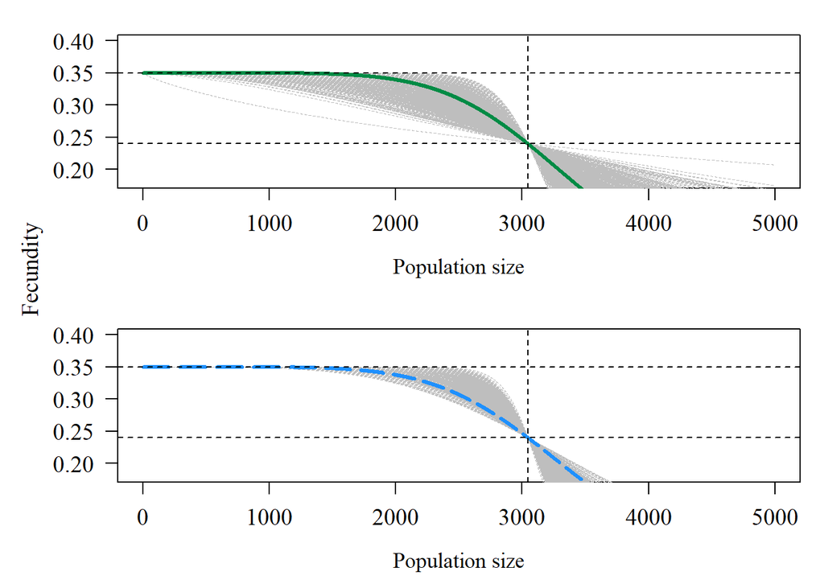

```r
set.seed(123)
Nts <- 0:5000
# Schwake et al 2017
par(mfrow = c(2, 1), mar = c(4.5, 5, 1.5, 1))
# 1000 realizations of rho
rhos2017 <- rgamma(1000, shape = 6.4, scale = 1)
# the mean rho
plot(Nts, ft(Nt = Nts, rho = 6.4, Nnom = 3045, Fmax = 0.35, Fnom = 0.24),
    type = "n", ylab = "", xlab = TeX("Population size"), ylim = c(0.18,
        0.4), las = 1, family = "A", cex.axis = 1.2, cex.main = 1.5,
    cex.lab = 1.1)
for (i in 1:1000) {
    lines(Nts, ft(Nt = Nts, rho = rhos2017[i], Nnom = 3045, Fmax = 0.35,
        Fnom = 0.24), lty = 2, lwd = 0.5, col = "grey")
}
points(Nts, ft(Nt = Nts, rho = 6.4, Nnom = 3045, Fmax = 0.35,
    Fnom = 0.24), type = "l", col = "springgreen4", lwd = 3,
    las = 1, family = "A", cex.axis = 1.2, cex.main = 1.5, cex.lab = 1.1)
abline(h = c(0.24, 0.35), v = 3045, lty = 2)
# new the mean rho
plot(Nts, ft(Nt = Nts, rho = 6.34/0.853, Nnom = 3045, Fmax = 0.35,
    Fnom = 0.24), type = "n", ylab = "", xlab = TeX("Population size"),
    ylim = c(0.18, 0.4), las = 1, family = "A", cex.axis = 1.2,
    cex.main = 1.5, cex.lab = 1.1)
for (i in 1:1000) {
    lines(Nts, ft(Nt = Nts, rho = rhos[i], Nnom = 3045, Fmax = 0.35,
        Fnom = 0.24), lty = 2, lwd = 0.5, col = "grey")
}
points(Nts, ft(Nt = Nts, rho = 6, Nnom = 3045, Fmax = 0.35, Fnom = 0.24),
    type = "l", col = "dodgerblue", lwd = 3, lty = 5, las = 1,
    family = "A", cex.axis = 1.2, cex.main = 1.5, cex.lab = 1.1)
abline(h = c(0.24, 0.35), v = 3045, lty = 2)

mtext(TeX("Fecundity"), side = 2, line = 3, at = 0.5, family = "A",
    cex = 1.2)
```

# Creating figure 4

Here we represent the expert elicited Probability of recovery for a BB BND

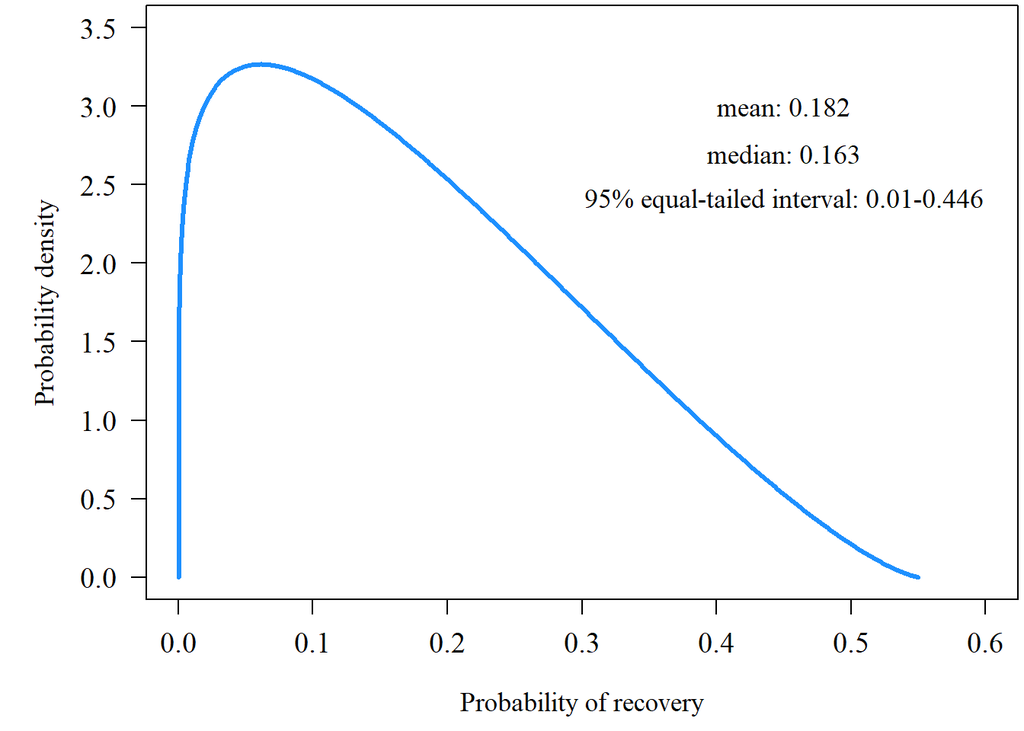

```r
par(mfrow = c(1, 1), mar = c(4.5, 5, 0.2, 0.2))
# Barataria Bay BND
l1 <- 0
u1 <- 0.55
a1 <- 1.17
b1 <- 2.36
x <- seq(0, 1, length = 1000)
y1 <- dbeta(x, a1, b1)/(u1 - l1)
plot(x * (u1 - l1) + l1, y1, type = "l", xlim = c(0, 0.6), lwd = 3,
    ylim = c(0, 3.5), col = "dodgerblue", ylab = "Probability density",
    xlab = "Probability of recovery", las = 1, family = "A",
    cex.axis = 1.2, cex.main = 1.5, cex.lab = 1.1)
set.seed(123)
ry1 <- (l1 + rbeta(1000000, a1, b1) * u1) - l1
text(0.45, 3, labels = paste("mean:", round(mean(ry1), 3)), cex = 1.1,
    family = "A")
text(0.45, 2.7, labels = paste("median:", round(median(ry1),
    3)), cex = 1.1, family = "A")
text(0.45, 2.4, labels = paste0("95% equal-tailed interval: ",
    round(quantile(ry1, p = 0.025), 3), "-", round(quantile(ry1,
        p = 0.975), 3)), cex = 1.1, family = "A")
```

# Creating figure 5

## Load libraries and source required files:

```r
library(dplyr)
library(tidyr)
library(ggplot2)
library(ggpubr)
library(readr)
library(gridExtra)
```

```r
source("Functions/SilerFuns.R")       # Siler model functions are here
```

## Loading required external information and files

```r
#initial population size
N_boot <- read_csv("InOutBySp/Bottlenose_dolphin_BB/N_boot.csv")
#Baseline survival
BaselineSurvival <- read_csv("InputFiles/BaselineSurvival.csv", col_names = FALSE)
BaselineSurvival$oil <- "Baseline"
#Post oil survival
PostOilSurv <- read_csv("InOutBySp/Bottlenose_dolphin_BB/PostOilSurv.csv", col_names = FALSE)
PostOilSurv$oil<- "Post-oil"
#make single object for plotting
survdata<- rbind(PostOilSurv,BaselineSurvival)
```

We also require the objects that record the simulations over time and corresponding injury metrics from our paper. We load those objects here:

```r
#note this loads a number of objects, including "simres" and "injury"
load("InOutBySp/Bottlenose_dolphin_BB/Ttrusimres10000Sim.RData")
```

## Data wrangling

Here we manipulate the objects to make them suitable for `ggplot`:

```r
#data<- data.frame(simres)
nyears <- dim(simres)[2]
nsims <- dim(simres)[3]
ylims1 <- as.data.frame(c(min(c(colSums(simres[, , 1:nsims, 2]), colSums(simres[, , 1:nsims, 1])))*0.9, max(c(colSums(simres[, , 1:nsims, 2]), colSums(simres[, , 1:nsims, 1])))*1.1))

firstyearsnooil<-data.frame(colSums(simres[, , 1, 2]))
firstyearsoil<- as.data.frame(colSums(simres[, , 1, 1]))

firstyearsnooil1<-(colSums(simres[, , 1, 2]))
firstyearsoil1<- (colSums(simres[, , 1, 1]))

#no oil
data1<- as.data.frame(1:nrow(firstyearsnooil))
colnames(data1)<-"year"
data1$population<-firstyearsnooil1
data1$nooil<- firstyearsnooil1

#oil

data2<- as.data.frame(1:nrow(firstyearsoil))
colnames(data2)<-"year"
data2$population<-firstyearsoil1
data2$withoil<-firstyearsoil1

data3<-merge(data1,data2,by="year",all=TRUE)

data1<- as.data.frame(1:nrow(firstyearsnooil))
colnames(data1)<-"year"
data1$population<-firstyearsnooil1
data1$nooil<- firstyearsnooil1
data1$ymax<- data3$population.x
data1$ymin<- data3$population.y
data1$oil<-"nospill"



data2<- as.data.frame(1:nrow(firstyearsoil))
colnames(data2)<-"year"
data2$oil<- "spill"
data2$population<-firstyearsoil1
data2$withoil<-firstyearsoil1
data2$ymax<- data3$population.x
data2$ymin<- data3$population.y
data<- merge(data1,data2,by=c("year","oil","population","ymin","ymax"), all=TRUE)
```

```r
data$diff<-data$ymax-data$ymin

data$oil<-factor(data$oil, levels=c("nospill", "spill"))
```

## Making the plot

### Creating individual plots

For initial population size

```r
numberplot<-ggplot(N_boot, aes(x=x))+geom_histogram(aes(y=..count..),bins=17,colour="black",alpha=0.6)+coord_flip()+ geom_vline(xintercept=median(N_boot$x), linetype="dashed",
                color = "red", size=1.2)+xlim(1000,4500)+xlab("Population size")+theme_bw()
```

For survival

```r
baselsurv<-ggplot(survdata, aes(x=X1,y=oil))+geom_boxplot(aes(fill=oil),color="black",alpha=0.6)+xlab("Survival")+coord_flip()+geom_jitter(aes(colour=oil),shape=".")+
  scale_fill_manual(values=c("darkblue","brown3"))+
  scale_color_manual(values=c("darkblue","brown3"))+theme_bw()+ylab("")+theme(legend.position = "none")
```

For population trajectories

```r
YTR<-median(injury$YTR)
YTR
```

```
## [1] 35
```

```r
# for plot
maxval<-unique(max(data4$diff))

data4$yearMPD<-ifelse(data4$diff>=maxval, data4$year,NA)

data4$y<-ifelse(data4$diff>=maxval, data4$ymin,NA)

data4$yend<-ifelse(data4$diff>=maxval, data4$ymax,NA)

MPD<-unique(data4$yearMPD[!is.na(data4$yearMPD)])
MPD
```

```
## [1] 11
```

```r
bestplot1<-ggplot(data4,aes(x=year,y=population,color=oil))+
  geom_ribbon(aes(ymin = ymin,ymax=ymax), fill = "red", alpha = .3,data = . %>% filter(year<= YTR))+
  geom_ribbon(aes(ymin = ymin,ymax=ymax), fill = "blue", alpha = .3,data = . %>% filter(year>=YTR))+
  geom_segment(aes(x=MPD,xend=MPD,y=data4$y,yend=data4$yend),colour="black")+
  geom_line(size=1.4)+
  theme_bw()+
  geom_vline(xintercept=YTR)+
  labs(colour="")+
  scale_color_manual(values=c("darkblue","brown3"))+
  ylab("Predicted population size")+
  xlab("Years since spill")+
  ylim(1000,4500)+
  annotate("segment", xend=YTR, x= 34.5, y= 4100, yend= 3200, arrow = arrow(type="closed", length = unit(0.1, "inches")))+
  annotate('label',
           label = 'atop(atop("", bold("LTR")), atop("Number of years for the population to", "recover with 95% baseline trajectory"))',
           y = 4200, x = 34.5, parse = T)+
  annotate('label',
           label = 'atop(atop("", "Lost"), atop("cetacean", "years"))',
           y = 1800, x = 30, parse = T)+
  annotate("segment", xend=12.5, x= 29, y= 1900, yend= 2800, arrow = arrow(type="closed", length = unit(0.1, "inches"))) +
  annotate('label',
           label = 'atop(atop("", bold("MPD")), atop("Largest proportional", "decrease"))',
           y = 4300, x = 7, parse = T)+
  annotate("segment", xend=MPD, x= 7, y= 4050, yend= 3200, arrow = arrow(type="closed", length = unit(0.1, "inches")))+ theme(legend.position = c(0.92, 0.2))+xlim(0,50)
```

All in one, i.e.

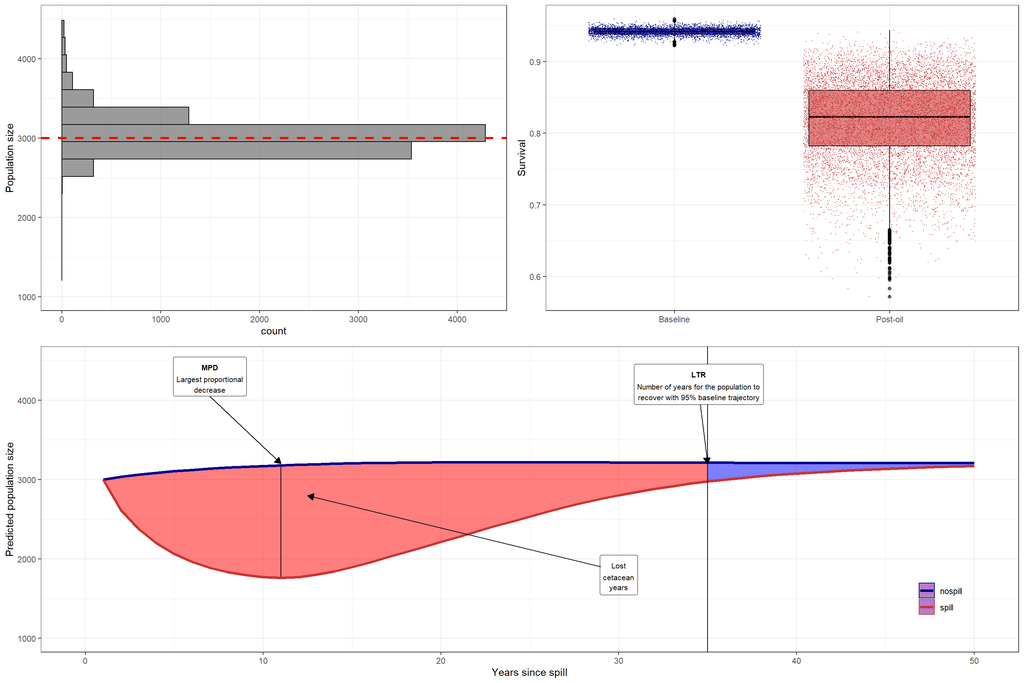

```r
layout_matrix <- matrix(c(1, 1, 2, 2, 4, 3, 3, 4), nrow = 2, byrow = TRUE)
grid.arrange(numberplot,baselsurv,bestplot1, layout_matrix = matrix(c(1,3,2,3), nrow = 2))
```

We decided for simplicity to not include the survival probability information in the main paper, considering simply the population trajectories, with added estimates from SECR population size and injury metrics, which corresponds to figure 4 in the manuscript. This is shown below:

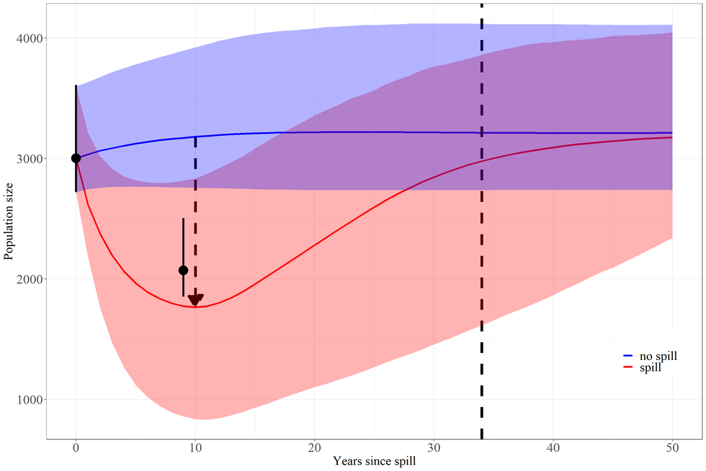

```r
bas2019<- read_csv("InOutBySp/Bottlenose_dolphin_BB/N_boot2019.csv")
N_boot <- read_csv("InOutBySp/Bottlenose_dolphin_BB/N_boot.csv")
dattat1<-N_boot%>%
summarise(Mean=mean(x), Max=max(x), Min=min(x), Median=median(x), Std=sd(x),quantile975=quantile(x,probs=0.975),quantile025=quantile(x,probs=0.025))

dattat<-bas2019%>%
summarise(Mean=mean(x), Max=max(x), Min=min(x), Median=median(x), Std=sd(x),quantile975=quantile(x,probs=0.975),quantile025=quantile(x,probs=0.025))


 ggplot() +
  #geom_ribbon(data = subset(data4,year<= YTR),aes(ymin = ymin,ymax=ymax,x=year), fill = "red", alpha = .4)+
  #geom_ribbon(data = subset(data4,year>= YTR),aes(ymin = ymin,ymax=ymax,x=year), fill = "blue", alpha = .4)+
annotate("segment",x=MPD-1,xend=MPD-1,yend=data4$y,y=data4$yend,colour="black",linetype = "dashed", lwd=2, arrow = arrow(type="closed", length = unit(0.3, "inches")))+
  geom_line(aes(x=data4$year-1,y=data4$population,color=data4$oil,lwd=2),size=1.4)+
  theme_bw()+
 #   annotate("segment", yend = 1000, y = 4500, x = YTR, xend = YTR,colour = "black", arrow = arrow(type="closed", length = unit(0.1, "inches")),linetype="dashed") +
  geom_vline(xintercept=YTR-1,linetype="dashed",lwd=2)+
  labs(colour="")+
  scale_color_manual(values=c("darkblue","brown3"))+
  ylab("Population size")+
  xlab("Years since spill")+
  #annotate("segment", xend=YTR, x= 34.5, y= 4100, yend= 3200, arrow = arrow(type="open", length = unit(0.1, "inches")))+
  #annotate('label',
        #   label = 'atop(atop("", bold("YTR")), atop("Number of years for the population to", "recover with 95% baseline trajectory"))',
       #    y = 4200, x = 34.5, parse = T)+
  #annotate('label',
   #        label = 'atop(atop("", "Lost"), atop("cetacean", "years"))',
    #       y = 1800, x = 30, parse = T)+
  #annotate("segment", xend=12.5, x=29, y= 1900, yend= 2800, arrow = arrow(type="open", length = unit(0.1, "inches"))) +
  #annotate('label',
   #        label = 'atop(atop("", bold("MPD")), atop("Largest proportional", "decrease"))',
    #       y = 4300, x = 7, parse = T)+
  #annotate("segment", xend=MPD, x= 7, y= 4050, yend= 2500, arrow = arrow(type="open", length = unit(0.1, "inches")))+
  theme(legend.position = c(0.92, 0.2))+xlim(0,50)+   geom_ribbon(data = subset(data4,oil=="spill"),aes(x=year-1,y=Median,ymin =quantile025,ymax=quantile975),fill="red", alpha = .3)+
  geom_ribbon(data = subset(data4,oil=="nospill"),aes(x=year-1,y=Median,ymin =quantile025,ymax=quantile975),fill="blue", alpha = .3)+
   #to change font size on labels and axis
  theme(axis.text.x = element_text(size = 30),
        axis.text.y = element_text(size = 30),
        axis.title.x = element_text(size = 30),
        axis.title.y = element_text(size = 30),
        legend.text=element_text(size=30)) +
  geom_pointrange(data=dattat, aes(x=9,
              y=Median,ymin=quantile025,ymax=quantile975),size=1.5) +
 geom_pointrange(data=dattat1, aes(x=0,
               y=Median,ymin=quantile025,ymax=quantile975),size=1.5)+
        scale_color_manual(values=c("blue","red"),labels=c('no spill', 'spill'))+
  theme(text = element_text(family = "A"),
        axis.title.x = element_text(size = 19),
        axis.text.x = element_text(size = 20),
        axis.text.y = element_text(size = 20),
        axis.title.y = element_text(size = 19),
        legend.title = element_text(size=19),
        legend.text= element_text(size=19),
        plot.title = element_text(size=24))
```

The results paragraph in the paper is:

The mean initial population size was 3045 (SD: 375.28119, 95% credible intervals of 2720;3611) (figure 4, top left panel). The mean of the survival pre oil spill was 0.942 (SD: 0.00528, 95% credible intervals of 0.931 – 0.952) while the mean of the survival post oil spill was 0.818 (SD: 0.05586, 95% credible intervals of 0.695 – 0.909), leading to an average reduction in survival post-oil spill of 0.868 (95% credible intervals of 0.739 – 0.965). The average population trajectory under the presence of the oil spill and assuming the oil spill never happened are shown in Figure 4 (bottom panel). There were 30993 median LCY (95% percentile CI 6607 – 94148), the maximum proportional decrease was 44.6 % (95% percentile CI 14.2 – 74) and it took a median of 35 (95% percentile CI 18 – 67) years for 95 % recovery.

```r
prop.in.2019<-100*(bas2019$x-N_boot$x)/N_boot$x
```

The mean population size in 2019, estimated by SCR, was 2099 animals (95% percentile CI 1852,2505). In comparison, that value given our model would be 1816 (95% percentile CI 893,2801).

# Acknowledgments

We thank Carolina Marques for the code and data wrangling that made the last plot much better.